### ANZ-InsideSherpa Task 2: Predictive analytics

### Done By: Megan Ng

## ==============================================================

## Data Wrangling using dplyr and Data Cleaning

## Load library

```r
r = getOption("repos")
r["CRAN"] = "http://cran.us.r-project.org"
options(repos = r)
install.packages('tidyverse')
install.packages("dplyr") #tidyverse
library(dplyr)
library(tidyr)
setwd("C:\\Users\\admin\\Desktop\\InsideSherpa (ANZ)\\Task 2\\data")
```

## Load Data

```r
data<-read.csv("ANZ synthesised transaction dataset.csv", sep= ';', header = TRUE) #note sep is ';'
#head(data)
#attach(data)
str(data) # gender already in factor , age is integer
```

```
## 'data.frame':    12043 obs. of  23 variables:
##  $ status           : Factor w/ 2 levels "authorized","posted": 1 1 1 1 1 2 1 1 1 2 ...
##  $ card_present_flag: int  1 0 1 1 1 NA 1 1 1 NA ...
##  $ bpay_biller_code : Factor w/ 4 levels ""," LAND WATER & PLANNING East Melbourne",..: 1 1 1 1 1 1 1 1 1 1 ...
##  $ account          : Factor w/ 100 levels "ACC-1037050564",..: 18 18 5 1 18 19 51 51 26 91 ...
##  $ currency         : Factor w/ 1 level "AUD": 1 1 1 1 1 1 1 1 1 1 ...
##  $ long_lat         : Factor w/ 100 levels "114.62 -28.80",..: 98 98 85 96 98 84 34 34 13 86 ...
##  $ txn_description  : Factor w/ 6 levels "INTER BANK","PAY/SALARY",..: 5 6 5 6 6 3 6 5 5 1 ...
##  $ merchant_id      : Factor w/ 5726 levels "","00097987-7795-4c01-92c7-66bf486bacca",..: 2837 2859 2865 1544 4010 1 1230 5327 4643 1 ...
##  $ merchant_code    : int  NA NA NA NA NA NA NA NA NA NA ...
##  $ first_name       : Factor w/ 80 levels "Abigail","Alexander",..: 21 21 53 62 21 65 42 42 78 53 ...
##  $ balance          : num  35.39 21.2 5.71 2117.22 17.95 ...
##  $ date             : Factor w/ 91 levels "1/10/2018","1/8/2018",..: 2 2 2 2 2 2 2 2 2 2 ...
##  $ gender           : Factor w/ 2 levels "F","M": 1 1 2 1 1 2 1 1 1 2 ...
##  $ age              : int  26 26 38 40 26 20 43 43 27 40 ...
##  $ merchant_suburb  : Factor w/ 1610 levels "","Abbotsford",..: 54 1381 1381 216 903 1 710 894 1603 1 ...
##  $ merchant_state   : Factor w/ 9 levels "","ACT","NSW",..: 5 3 3 5 5 1 8 8 9 1 ...
##  $ extraction       : Factor w/ 9442 levels "2018-08-01T01:01:15.000+0000",..: 1 2 3 4 5 6 7 8 9 10 ...
##  $ amount           : num  16.25 14.19 6.42 40.9 3.25 ...
##  $ transaction_id   : Factor w/ 12043 levels "0001043c134f43bda3e3d87b2ee79c9c",..: 7803 919 11982 1866 2426 762 8624 10596 5712 5709 ...
##  $ country          : Factor w/ 1 level "Australia": 1 1 1 1 1 1 1 1 1 1 ...
##  $ customer_id      : Factor w/ 100 levels "CUS-1005756958",..: 47 47 37 19 47 55 84 84 60 33 ...
##  $ merchant_long_lat: Factor w/ 2704 levels "","113.83 -22.76",..: 2594 2023 2023 2355 2660 1 852 870 210 1 ...
##  $ movement         : Factor w/ 2 levels "credit","debit": 2 2 2 2 2 2 2 2 2 2 ...
```

## Data preparation

```r
#Location data
data_cust_id<-data%>%select(customer_id) #library MASS and car will mask dplyr use without
data_location<-data%>%separate(col=long_lat,c('longitude', 'latitude'),sep =" ") %>%
  select(longitude,latitude)%>%mutate(latitude= substr(data$long_lat, 9,13))
data_location_numeric<-data.frame<-sapply(data_location,as.numeric)
data_id_location<-cbind(data_cust_id,data_location_numeric)
data_location_unique<-data_id_location%>%unique()
#write.csv(data_id_location, "data_location.csv")
#nrow(data_location_unique)
```

```r
## testing out data to see how many/frequency of pay/salary records per customer since possible to vary
data_salary<-data%>% filter(txn_description == "PAY/SALARY") # we r interested only in salary not POS etc
#head(data_salary)
cust_1_data<-data_salary %>% filter(customer_id == "CUS-1462656821") # this cust id only has 7 salary records for over 3 mths
cust_1_data
```

```
##   status card_present_flag bpay_biller_code       account currency
## 1 posted                NA                0 ACC-588564840      AUD
## 2 posted                NA                0 ACC-588564840      AUD
## 3 posted                NA                0 ACC-588564840      AUD
## 4 posted                NA                0 ACC-588564840      AUD
## 5 posted                NA                0 ACC-588564840      AUD
## 6 posted                NA                0 ACC-588564840      AUD
## 7 posted                NA                0 ACC-588564840      AUD
##        long_lat txn_description merchant_id merchant_code first_name  balance
## 1 151.27 -33.76      PAY/SALARY                         0     Isaiah  8342.11
## 2 151.27 -33.76      PAY/SALARY                         0     Isaiah 10724.87
## 3 151.27 -33.76      PAY/SALARY                         0     Isaiah 13030.74
## 4 151.27 -33.76      PAY/SALARY                         0     Isaiah 15523.69
## 5 151.27 -33.76      PAY/SALARY                         0     Isaiah 17906.31
## 6 151.27 -33.76      PAY/SALARY                         0     Isaiah 21236.51
```

[output cut: 25 more lines]

```r
cust_2_data<-data_salary %>% filter(customer_id=="CUS-2500783281") # 14 salary records over 3 mths
cust_2_data
```

```
##    status card_present_flag bpay_biller_code        account currency
## 1  posted                NA                0 ACC-1650504218      AUD
## 2  posted                NA                0 ACC-1650504218      AUD
## 3  posted                NA                0 ACC-1650504218      AUD
## 4  posted                NA                0 ACC-1650504218      AUD
## 5  posted                NA                0 ACC-1650504218      AUD
## 6  posted                NA                0 ACC-1650504218      AUD
## 7  posted                NA                0 ACC-1650504218      AUD
## 8  posted                NA                0 ACC-1650504218      AUD
## 9  posted                NA                0 ACC-1650504218      AUD
## 10 posted                NA                0 ACC-1650504218      AUD
## 11 posted                NA                0 ACC-1650504218      AUD
## 12 posted                NA                0 ACC-1650504218      AUD
## 13 posted                NA                0 ACC-1650504218      AUD
## 14 posted                NA                0 ACC-1650504218      AUD
```

[output cut: 60 more lines]

```r
# here we conclude to find annual salary of each customer, we have to find their respective average salary over 3mths x 12 = annual salary

unique_id<-unique(data_salary$customer_id)
df_unique_id<-data.frame(customer_id= unique_id)
#df_unique_id

data_sales<-data %>% filter(txn_description== 'SALES-POS' | txn_description== 'POS')


## records only span across 3 mths august,sep,oct , so annual salary = sum(amount)/3 *12

data_annual_salary<-data_salary %>% group_by(customer_id) %>% summarise(annual_salary = (sum(amount)/3) *12)
## this gives attributes of spending patterns /habits of customers
data_var<-data_sales%>% select(customer_id,age,gender,amount,balance)%>%group_by(customer_id)%>%
  mutate(monthly_transaction_volume=n()/3,monthly_transaction_amt=sum(amount)/3,median_balance=median(balance,na.rm=T))%>%
  select(-c("amount","balance"))%>%unique()
final_data<-data_var%>%merge(data_annual_salary)%>%merge(data_location_unique)

final_data$age_group<- ifelse( final_data[,"age"]>=18 & final_data[,"age"]<=30, "young adults",
                               ifelse(final_data[,"age"]>=31 & final_data[,"age"]<=50,"middle-aged adults","older adults"))
head(final_data)
```

```
##      customer_id age gender monthly_transaction_volume monthly_transaction_amt
## 1 CUS-1005756958  53      F                   16.00000                 603.620
## 2 CUS-1117979751  21      M                   17.33333                1325.273
## 3 CUS-1140341822  28      M                   21.66667                1463.180
## 4 CUS-1147642491  34      F                   25.33333                1295.250
## 5 CUS-1196156254  34      F                   54.33333                1646.870
## 6 CUS-1220154422  25      F                   16.00000                1054.863
##   median_balance annual_salary longitude latitude          age_group
## 1       1054.965      50464.44    153.03    27.51       older adults
## 2       8444.820     100202.20    115.81    31.82       young adults
## 3       6820.260      45996.24    144.97    37.42       young adults
## 4       9572.950      88992.28    151.04    33.77 middle-aged adults
## 5      22055.110     109304.44    138.52    35.01 middle-aged adults
## 6       8476.365      63906.08    150.50    23.40       young adults
```

```r
str(final_data) # check all data types are correct before performing regression analysis need to change
```

```
## 'data.frame':    100 obs. of  10 variables:
##  $ customer_id               : Factor w/ 100 levels "CUS-1005756958",..: 1 2 3 4 5 6 7 8 9 10 ...
##  $ age                       : int  53 21 28 34 34 25 44 30 20 21 ...
##  $ gender                    : Factor w/ 2 levels "F","M": 1 2 2 1 1 1 2 1 1 1 ...
##  $ monthly_transaction_volume: num  16 17.3 21.7 25.3 54.3 ...
##  $ monthly_transaction_amt   : num  604 1325 1463 1295 1647 ...
##  $ median_balance            : num  1055 8445 6820 9573 22055 ...
##  $ annual_salary             : num  50464 100202 45996 88992 109304 ...
##  $ longitude                 : num  153 116 145 151 139 ...
##  $ latitude                  : num  27.5 31.8 37.4 33.8 35 ...
##  $ age_group                 : chr  "older adults" "young adults" "young adults" "middle-aged adults" ...
```

```r
final_data$age_group =as.factor(final_data$age_group) # age group need to change to factors later
```

# Data exploration

## scatterplot matrix

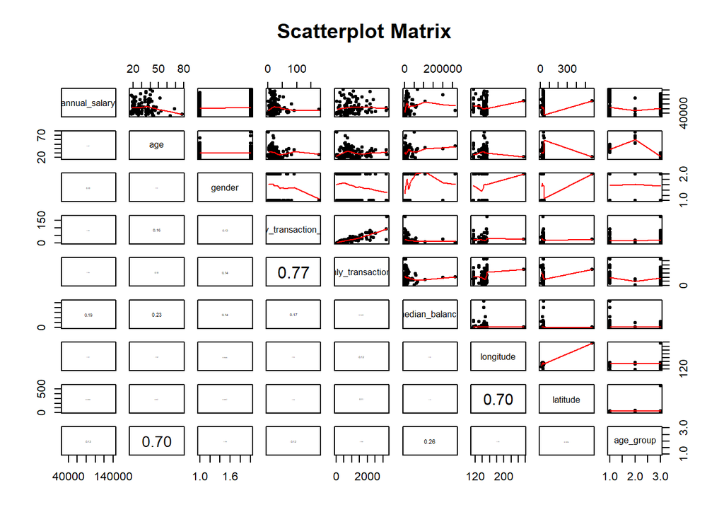

```r
panel.cor <- function(x, y, digits=2, prefix="", cex.cor, ...)
{
  usr <- par("usr"); on.exit(par(usr))
  par(usr = c(0, 1, 0, 1))
  r <- abs(cor(x, y))
  txt <- format(c(r, 0.123456789), digits=digits)[1]
  txt <- paste(prefix, txt, sep="")
  if(missing(cex.cor)) cex.cor <- 0.8/strwidth(txt)
  text(0.5, 0.5, txt, cex = cex.cor * r)
}


pairs(annual_salary~age+gender+monthly_transaction_volume+monthly_transaction_amt+median_balance+longitude+latitude+age_group, data=final_data,
      lower.panel=panel.cor, upper.panel=panel.smooth,
      pch=20, main=" Scatterplot Matrix")
```

```r
#x<-cbind(annual_salary,age,gender,monthly_transaction_volume,monthly_transaction_amt,median_balance,longitude,latitude,age_group)

#cor(x)
```

## ===================================

## ===================================

```r
##model 1
model_1<-lm(annual_salary~.-customer_id,data=final_data)
summary(model_1)
```

```
##
## Call:
## lm(formula = annual_salary ~ . - customer_id, data = final_data)
##
## Residuals:
##    Min     1Q Median     3Q    Max
## -45899 -18640  -7235  14094  67419
##
## Coefficients:
##                              Estimate Std. Error t value Pr(>|t|)
## (Intercept)                 1.655e+05  4.009e+04   4.130 8.12e-05 ***
## age                        -1.334e+03  6.041e+02  -2.208   0.0298 *
## genderM                     4.403e+03  5.426e+03   0.811   0.4192
## monthly_transaction_volume -1.241e+02  1.809e+02  -0.686   0.4946
## monthly_transaction_amt     4.721e+00  6.165e+00   0.766   0.4458
## median_balance              1.309e-01  7.978e-02   1.641   0.1043
## longitude                  -3.697e+02  2.332e+02  -1.585   0.1164
## latitude                    1.147e+02  7.016e+01   1.635   0.1055
## age_groupolder adults       1.835e+04  1.950e+04   0.941   0.3494
## age_groupyoung adults      -2.741e+04  1.107e+04  -2.477   0.0151 *
## ---
## Signif. codes:  0 '***' 0.001 '**' 0.01 '*' 0.05 '.' 0.1 ' ' 1
##
## Residual standard error: 26220 on 90 degrees of freedom
## Multiple R-squared:  0.1406, Adjusted R-squared:  0.05463
## F-statistic: 1.636 on 9 and 90 DF,  p-value: 0.117
```

```r
anova(model_1)
```

```
## Analysis of Variance Table
##
## Response: annual_salary
##                            Df     Sum Sq    Mean Sq F value  Pr(>F)
## age                         1 9.5930e+07   95929574  0.1395 0.70961
## gender                      1 7.5892e+08  758917486  1.1040 0.29621
## monthly_transaction_volume  1 1.9555e+08  195554564  0.2845 0.59511
## monthly_transaction_amt     1 1.0183e+09 1018256341  1.4812 0.22677
## median_balance              1 2.2151e+09 2215084334  3.2222 0.07600 .
## longitude                   1 1.9941e+08  199407296  0.2901 0.59151
## latitude                    1 1.2576e+09 1257584719  1.8293 0.17959
## age_group                   2 4.3790e+09 2189476835  3.1849 0.04609 *
## Residuals                  90 6.1871e+10  687451068
## ---
## Signif. codes:  0 '***' 0.001 '**' 0.01 '*' 0.05 '.' 0.1 ' ' 1
```

The first model included all variables. From the summary table, we can see all variables are insignificant at 5% significance level except the intercept term, age and age group,suggesting too many redundant variables. Also F-statistic is 1.636 with p-value >0.05 hence this model is insignificant at 5% significance level. As such, next we will perform stepwise regression to choose the model with the lowest AIC.

```r
#model_step<-MASS::stepAIC(model_1)summary(model_2)
step_model_1<-step(model_1,direction=c("both"))
```

```
## Start:  AIC=2044.31
## annual_salary ~ (customer_id + age + gender + monthly_transaction_volume +
##     monthly_transaction_amt + median_balance + longitude + latitude +
##     age_group) - customer_id
##
##                              Df  Sum of Sq        RSS    AIC
## - monthly_transaction_volume  1  323285441 6.2194e+10 2042.8
## - monthly_transaction_amt     1  403207895 6.2274e+10 2043.0
## - gender                      1  452689881 6.2323e+10 2043.0
## <none>                                     6.1871e+10 2044.3
## - longitude                   1 1727501246 6.3598e+10 2045.1
## - latitude                    1 1838174681 6.3709e+10 2045.2
## - median_balance              1 1851132946 6.3722e+10 2045.3
## - age_group                   2 4378953669 6.6250e+10 2047.2
## - age                         1 3352945040 6.5224e+10 2047.6
##
## Step:  AIC=2042.84
## annual_salary ~ age + gender + monthly_transaction_amt + median_balance +
##     longitude + latitude + age_group
##
##                              Df  Sum of Sq        RSS    AIC
## - monthly_transaction_amt     1   94761058 6.2289e+10 2041.0
## - gender                      1  458555012 6.2652e+10 2041.6
## <none>                                     6.2194e+10 2042.8
## - longitude                   1 1753267271 6.3947e+10 2043.6
## - median_balance              1 2019554730 6.4213e+10 2044.0
## - latitude                    1 2103233996 6.4297e+10 2044.2
## + monthly_transaction_volume  1  323285441 6.1871e+10 2044.3
## - age                         1 3290858725 6.5485e+10 2046.0
## - age_group                   2 4650261656 6.6844e+10 2046.0
##
## Step:  AIC=2040.99
## annual_salary ~ age + gender + median_balance + longitude + latitude +
##     age_group
##
##                              Df  Sum of Sq        RSS    AIC
## - gender                      1  410177451 6.2699e+10 2039.6
## <none>                                     6.2289e+10 2041.0
## - longitude                   1 1715079096 6.4004e+10 2041.7
## - median_balance              1 1959706544 6.4248e+10 2042.1
## - latitude                    1 2151212312 6.4440e+10 2042.4
## + monthly_transaction_amt     1   94761058 6.2194e+10 2042.8
## + monthly_transaction_volume  1   14838604 6.2274e+10 2043.0
## - age                         1 3276606102 6.5565e+10 2044.1
## - age_group                   2 4724575982 6.7013e+10 2044.3
##
## Step:  AIC=2039.64
## annual_salary ~ age + median_balance + longitude + latitude +
##     age_group
##
##                              Df  Sum of Sq        RSS    AIC
## <none>                                     6.2699e+10 2039.6
## - longitude                   1 1621397629 6.4320e+10 2040.2
## + gender                      1  410177451 6.2289e+10 2041.0
## - latitude                    1 2191329067 6.4890e+10 2041.1
## - median_balance              1 2294072649 6.4993e+10 2041.2
## + monthly_transaction_amt     1   46383497 6.2652e+10 2041.6
## + monthly_transaction_volume  1   37476068 6.2661e+10 2041.6
## - age                         1 3360228197 6.6059e+10 2042.9
## - age_group                   2 4717955564 6.7417e+10 2042.9
```

```r
summary(step_model_1)
```

```
##
## Call:
## lm(formula = annual_salary ~ age + median_balance + longitude +
##     latitude + age_group, data = final_data)
##
## Residuals:
##    Min     1Q Median     3Q    Max
## -44963 -18231  -6460  15067  69571
##
## Coefficients:
##                         Estimate Std. Error t value Pr(>|t|)
## (Intercept)            1.677e+05  3.959e+04   4.236 5.35e-05 ***
## age                   -1.334e+03  5.975e+02  -2.233   0.0280 *
## median_balance         1.429e-01  7.745e-02   1.845   0.0683 .
## longitude             -3.569e+02  2.302e+02  -1.551   0.1243
## latitude               1.238e+02  6.869e+01   1.803   0.0746 .
## age_groupolder adults  1.719e+04  1.909e+04   0.901   0.3700
## age_groupyoung adults -2.807e+04  1.094e+04  -2.567   0.0119 *
## ---
## Signif. codes:  0 '***' 0.001 '**' 0.01 '*' 0.05 '.' 0.1 ' ' 1
##
## Residual standard error: 25960 on 93 degrees of freedom
## Multiple R-squared:  0.1291, Adjusted R-squared:  0.07288
## F-statistic: 2.297 on 6 and 93 DF,  p-value: 0.04113
```

```r
anova(step_model_1)
```

```
## Analysis of Variance Table
##
## Response: annual_salary
##                Df     Sum Sq    Mean Sq F value  Pr(>F)
## age             1 9.5930e+07   95929574  0.1423 0.70687
## median_balance  1 2.8648e+09 2864761721  4.2492 0.04206 *
## longitude       1 4.5656e+07   45655968  0.0677 0.79526
## latitude        1 1.5672e+09 1567161205  2.3245 0.13074
## age_group       2 4.7180e+09 2358977782  3.4990 0.03426 *
## Residuals      93 6.2699e+10  674180861
## ---
## Signif. codes:  0 '***' 0.001 '**' 0.01 '*' 0.05 '.' 0.1 ' ' 1
```

## ------------------------------

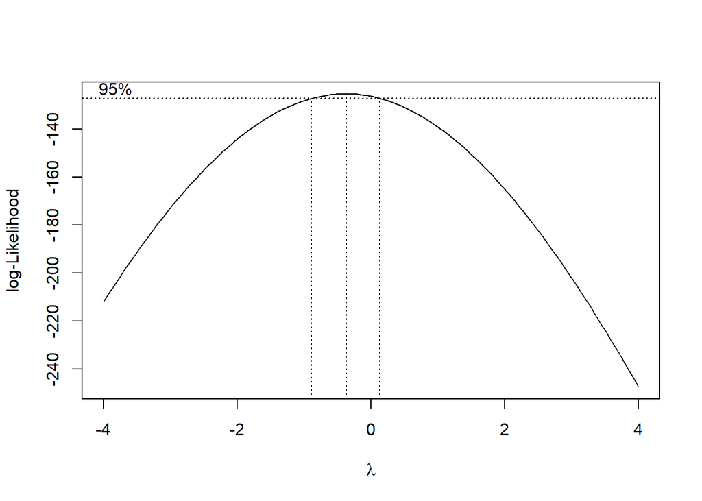

```r
MASS::boxcox(step_model_1, lambda=seq(-4, 4, by=0.5),optimize=TRUE,plotit = TRUE) #lambda =0
```

Box cox suggest lambda to be 0 hence a log transformation will be perform on y (y-> log(y)).

```r
model_2<-lm(log(annual_salary)~age+median_balance+longitude+latitude+age_group,data=final_data)
summary(model_2)
```

```
##
## Call:
## lm(formula = log(annual_salary) ~ age + median_balance + longitude +
##     latitude + age_group, data = final_data)
##
## Residuals:
##     Min      1Q  Median      3Q     Max
## -0.6818 -0.2561 -0.0573  0.2739  0.8277
##
## Coefficients:
##                         Estimate Std. Error t value Pr(>|t|)
## (Intercept)            1.256e+01  5.601e-01  22.429   <2e-16 ***
## age                   -2.088e-02  8.452e-03  -2.470   0.0153 *
## median_balance         2.115e-06  1.096e-06   1.931   0.0566 .
## longitude             -5.353e-03  3.256e-03  -1.644   0.1035
## latitude               1.821e-03  9.717e-04   1.874   0.0640 .
## age_groupolder adults  2.645e-01  2.700e-01   0.979   0.3299
## age_groupyoung adults -3.915e-01  1.547e-01  -2.531   0.0131 *
## ---
## Signif. codes:  0 '***' 0.001 '**' 0.01 '*' 0.05 '.' 0.1 ' ' 1
##
## Residual standard error: 0.3673 on 93 degrees of freedom
## Multiple R-squared:  0.1378, Adjusted R-squared:  0.08222
## F-statistic: 2.478 on 6 and 93 DF,  p-value: 0.02871
```

```r
step_model_2<-step(model_2,direction=c("both")) # model_2 and step_model_2 both propose same
```

```
## Start:  AIC=-193.57
## log(annual_salary) ~ age + median_balance + longitude + latitude +
##     age_group
##
##                  Df Sum of Sq    RSS     AIC
## <none>                        12.547 -193.57
## - longitude       1   0.36472 12.912 -192.70
## - latitude        1   0.47400 13.021 -191.86
## - median_balance  1   0.50292 13.050 -191.64
## - age_group       2   0.90096 13.448 -190.63
## - age             1   0.82332 13.370 -189.21
```

```r
summary(step_model_2)
```

```
##
## Call:
## lm(formula = log(annual_salary) ~ age + median_balance + longitude +
##     latitude + age_group, data = final_data)
##
## Residuals:
##     Min      1Q  Median      3Q     Max
## -0.6818 -0.2561 -0.0573  0.2739  0.8277
##
## Coefficients:
##                         Estimate Std. Error t value Pr(>|t|)
## (Intercept)            1.256e+01  5.601e-01  22.429   <2e-16 ***
## age                   -2.088e-02  8.452e-03  -2.470   0.0153 *
## median_balance         2.115e-06  1.096e-06   1.931   0.0566 .
## longitude             -5.353e-03  3.256e-03  -1.644   0.1035
## latitude               1.821e-03  9.717e-04   1.874   0.0640 .
## age_groupolder adults  2.645e-01  2.700e-01   0.979   0.3299
## age_groupyoung adults -3.915e-01  1.547e-01  -2.531   0.0131 *
## ---
## Signif. codes:  0 '***' 0.001 '**' 0.01 '*' 0.05 '.' 0.1 ' ' 1
##
## Residual standard error: 0.3673 on 93 degrees of freedom
## Multiple R-squared:  0.1378, Adjusted R-squared:  0.08222
## F-statistic: 2.478 on 6 and 93 DF,  p-value: 0.02871
```

```r
## conclusion model_2 best model
```

step_model_2 appear to be a better model than step_model_1 as its R^2 has improved. However both model's R^2 are still too low to explain the variability in response y.

## =================================

## =================================

## Check for constant/stable variance

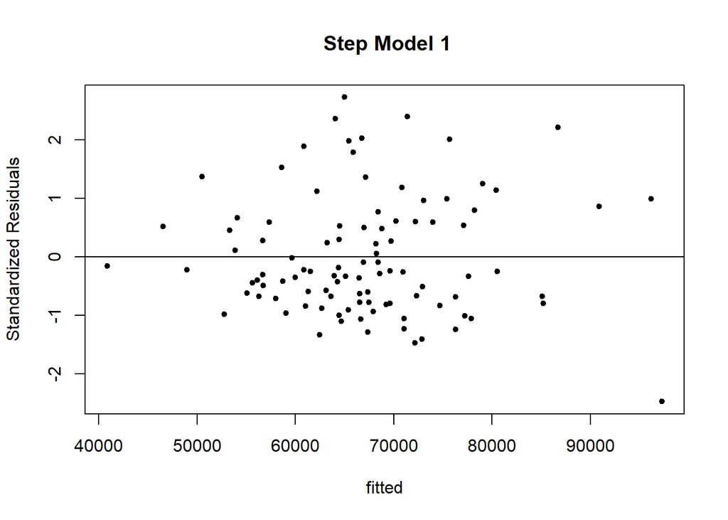

```r
plot(step_model_1$fitted.values,rstandard(step_model_1), xlab="fitted", ylab= "Standardized Residuals", main = " Step Model 1",pch=20)
abline(h=0)
```

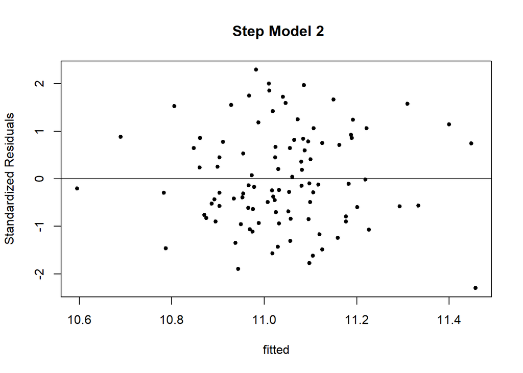

```r
#plot(model_2$fitted.values,rstandard(model_2), xlab="fitted", ylab= "Standardized Residuals", main = " Model 2",pch=20)
#abline(h=0)

#step_model_2 same model as model 2
plot(step_model_2$fitted.values,rstandard(step_model_2), xlab="fitted", ylab= "Standardized Residuals", main = " Step Model 2",pch=20)
abline(h=0)
```

From the residual against fitted values plot both model has relative stable variance with majority of points lying between -2 and 2.

## Check that normality assumption not violated

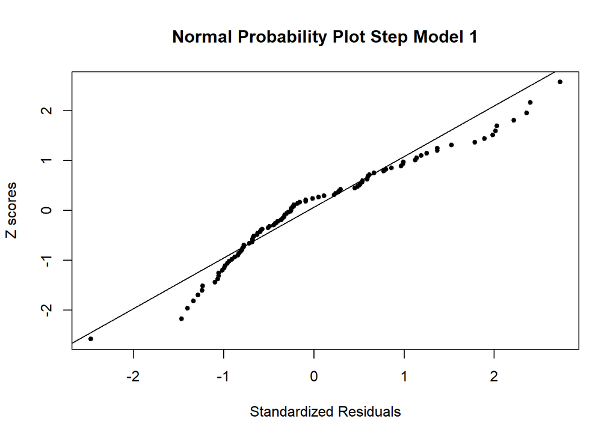

```r
#Normal probability plot =  QQ plot
qqnorm(rstandard(step_model_1),datax = TRUE, ylab = "Standardized Residuals", xlab = "Z scores", main = "Normal Probability Plot Step Model 1",pch=20)
qqline(rstandard(step_model_1),datax = TRUE)
```

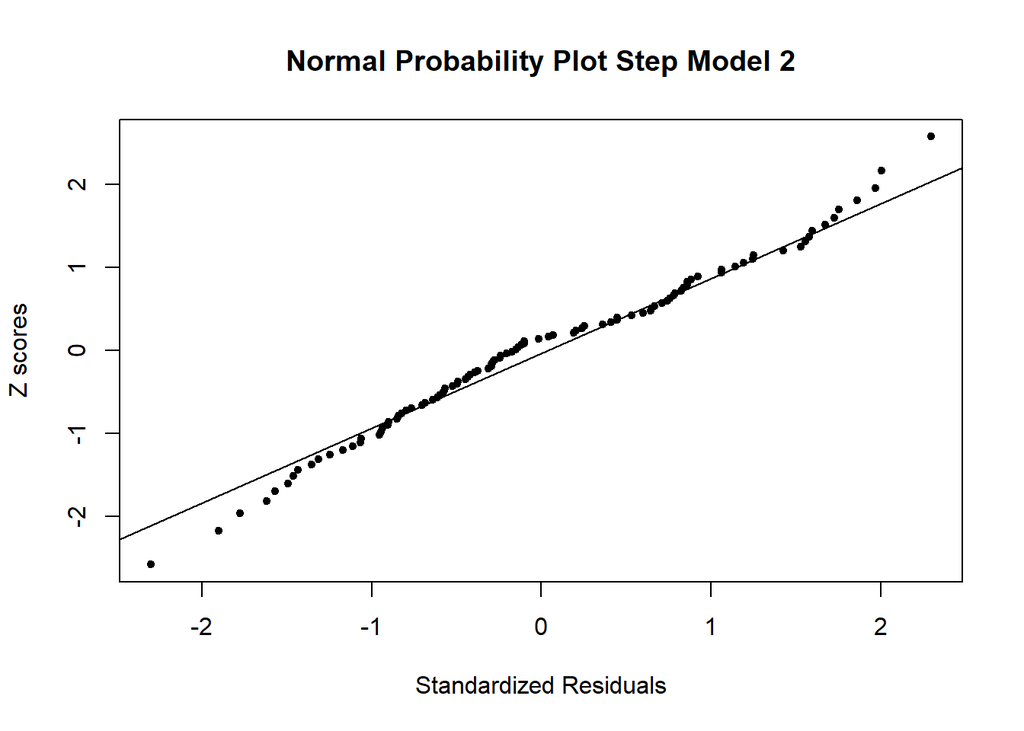

```r
qqnorm(rstandard(step_model_2),datax = TRUE, ylab = "Standardized Residuals", xlab = "Z scores", main = "Normal Probability Plot Step Model 2",pch=20)
qqline(rstandard(step_model_2),datax = TRUE)
```

The normal probability plot of residuals indicates no deviation from normality assumption as points lie relatively close to straight line.

## Ensure no mulit-collinearity VIF<10

```r
car:: vif(step_model_1) # VIF <10
```

```
##                    GVIF Df GVIF^(1/(2*Df))
## age            6.986511  1        2.643201
## median_balance 1.118276  1        1.057486
## longitude      2.040098  1        1.428320
## latitude       2.040874  1        1.428592
## age_group      7.305776  2        1.644056
```

```r
car::vif(step_model_2)
```

```
##                    GVIF Df GVIF^(1/(2*Df))
## age            6.986511  1        2.643201
## median_balance 1.118276  1        1.057486
## longitude      2.040098  1        1.428320
## latitude       2.040874  1        1.428592
## age_group      7.305776  2        1.644056
```

By looking at variance inflation factors, there does not seem to be any indication of strong multicollinearity in both models, since no variables show VIF values > 10.

## (c) Prediction Errors (= Residual Standard Error / mean) --> coefficient of variation

## ---------------------------------------------------------------------------------------

```r
predictionError_stepmodel_1 <- sigma(step_model_1)/mean(final_data$annual_salary)
predictionError_stepmodel_1     #0.3871727
```

```
## [1] 0.3871727
```

```r
# note: here, RSE = sigma(model_1)

predictionError_stepmodel_2 <- sigma(step_model_2)/mean(final_data$annual_salary)
predictionError_stepmodel_2          #5.477038e-06
```

```
## [1] 5.477038e-06
```

## Step Model 2 is better (as it has lower error rate)

## The lower the better --> model 2 better.

## Alternatively if you wish to use mse (mean square error)

## --------------------------------------------------------

## In this case, if we are to use mse, we will select step model 2 as it

## provides a lower error rate.

## RMSE

```r
RMSE <- function(error) { sqrt(mean(error^2)) }  ## Function for Root Mean Squared Error
RMSE(step_model_1$residuals) #25039.73
```

```
## [1] 25039.73
```

```r
RMSE(step_model_2$residuals)  #0.354218
```

```
## [1] 0.354218
```

# Train-Test Split

## 1. create training and testing set

## ====================================================

```r
nrow(final_data) #100  80% train 20% test
```

```
## [1] 100
```

```r
set.seed(1234) # set seed for reproducibility
index <- sample(100, 80)

train_final_data <- final_data[index,]
test_final_data <- final_data[-index,]
#View(train_final_data)
#View(test_final_data)
```

## 2.train our model using training data

## ==============================================

```r
trained_model <- lm(annual_salary~age+median_balance+longitude+latitude+age_group,data=train_final_data)
```

# 3. run the trained model on testing data

## ============================================

```r
pred.test <- predict(trained_model, newdata = test_final_data)

length(pred.test)
```

```
## [1] 20
```

```r
head(pred.test)
```

```
##       11       13       15       18       24       30
## 74996.82 59280.94 70777.97 97178.99 47712.11 62838.18
```

## 4. display result in an additional column in a dataframe

## ===========================================================

```r
result_test <- data.frame(
  actual_annual_salary = test_final_data$annual_salary,
  predicted_annual_salary = pred.test
)

mse_function <- function (x) {
  mean((as.numeric(x[1]) - as.numeric(x[2]))^2)
}


result_test$mse_column <- apply(result_test[,c("actual_annual_salary", "predicted_annual_salary")], 1, mse_function)
View(result_test)


mse <- mean(result_test$mse_column)
mse
```

```
## [1] 1211944342
```

# Conclusion

In conclusion the RMSE of the model is too high suggesting high error rate of the model and largely inaccurate to use for predicting annual salary. Furthermore R^2 and adjusted R^2 are significantly low and explains only 13% of the variability of response y (annual salary). Hence, we would require more data to built a better model.